# Sergi_Mas - PRAC2

Al llarg d'aquest notebook, aniré realitzant els diferents passos proposats en el document 'Descripció de la pràctica a realitzar'. He cregut més convenient la utilització d'un notebook de Jupyter enlloc d'un format .py estàndar perquè amb el notebook es pot intercalar text estàndar amb codi i visualització del mateix i fa que la seva visualització sigui més agraïda.

De fet, la majoria de codis de Python que realitzen EDA (Exploratory and Data Analysis) es fan amb el JUpyeterr Notebook gràcies a la seva versatilitat i fàcil visualització.

```python
# Importació de les llibreries a utilitzar
import pandas as pd
import numpy as np
import scipy as sp
import seaborn as sns
```

**PAS 1. LECTURA i REDUCCIÓ DEL DATASET**

```python
# Lectura del dataset
FA = pd.read_csv('db_FA.csv')

#Visualitzem les primeres 5 línies del nostre conjunt
FA.head()
```

|  | Id | Titol | Any | Duracio (min) | Pais | Direcció | Guió | Música | Fotografia | Productora | Repartiment | Gènere | Nota | Num. vots | Web |
| --- | --- | --- | --- | --- | --- | --- | --- | --- | --- | --- | --- | --- | --- | --- | --- |
| 0 | 520214.0 | Joker | 2019.0 | 121.0 | Estados Unidos | ['Todd Phillips'] | ['Todd Phillips', 'Scott Silver'] | ['Hildur Guðnadóttir'] | ['Lawrence Sher'] | ['DC Comics / DC Entertainment / Warner Bros. ... | ['Joaquin Phoenix', 'Robert De Niro', 'Zazie B... | [['Thriller'], ['Drama']] | 8,3 | 35.286 | https://www.filmaffinity.com/es/film520214.html |
| 1 | 977502.0 | Terminator: Dark Fate | 2019.0 | 128.0 | Estados Unidos | ['Tim Miller'] | ['David S. Goyer', 'Billy Ray', 'Justin Rhodes... | ['Junkie XL'] | ['Ken Seng'] | ['Coproducción Estados Unidos-China; 20th Cent... | ['Linda Hamilton', 'Mackenzie Davis', 'Natalia... | [['Ciencia ficción'], ['Acción']] | 5,7 | 1.929 | https://www.filmaffinity.com/es/film977502.html |
| 2 | 610683.0 | It. Chapter Two | 2019.0 | 169.0 | Estados Unidos | ['Andy Muschietti'] | ['Gary Dauberman', 'Jeffrey Jurgensen (Novela:... | ['Benjamin Wallfisch'] | ['Checco Varese'] | ['New Line Cinema / KatzSmith Productions / Li... | ['Jessica Chastain', 'James McAvoy', 'Isaiah M... | [['Terror'], ['Fantástico']] | 6,0 | 8.206 | https://www.filmaffinity.com/es/film610683.html |
| 3 | 316246.0 | The Lion King | 2019.0 | 118.0 | Estados Unidos | ['Jon Favreau'] | ['Jeff Nathanson (Historia: Brenda Chapman. Pe... | ['Hans Zimmer (Canciones: Tim Rice', 'Elton Jo... | ['Animation', 'Caleb Deschanel'] | ['Walt Disney Pictures / Fairview Entertainment'] | ['Animation'] | [['Animación'], ['Aventuras'], ['Drama'], ['Mu... | 6,6 | 11.710 | https://www.filmaffinity.com/es/film316246.html |
| 4 | 424407.0 | El Camino: A Breaking Bad Movie | 2019.0 | 122.0 | Estados Unidos | ['Vince Gilligan'] | ['Vince Gilligan'] | ['Dave Porter'] | ['Marshall Adams'] | ['Netflix / AMC / Sony Pictures Television. Di... | ['Aaron Paul', 'Matt Jones', 'Charles Baker', ... | [['Thriller'], ['Drama']] | 6,5 | 9.581 | https://www.filmaffinity.com/es/film424407.html |

```python
# Visualitzem les 5 últimes files del nostre conjunt
FA.tail()
```

|  | Id | Titol | Any | Duracio (min) | Pais | Direcció | Guió | Música | Fotografia | Productora | Repartiment | Gènere | Nota | Num. vots | Web |
| --- | --- | --- | --- | --- | --- | --- | --- | --- | --- | --- | --- | --- | --- | --- | --- |
| 5166 | 825097.0 | The Twilight Zone: Nightmare at 30,000 Feet (TV) | 2019.0 | 37.0 | Estados Unidos | ['Greg Yaitanes'] | ['Jordan Peele', 'Marco Ramirez (Historia: Ric... | ['Marco Beltrami', 'Brandon Roberts'] | ['Craig Wrobleski'] | ['CBS Television Studios / Monkeypaw Productio... | ['Adam Scott', 'Nabil Ayoub', 'J. Cameron Barn... | [['Fantástico'], ['Drama'], ['Intriga']] | 5,6 | 396.0 | https://www.filmaffinity.com/es/film825097.html |
| 5167 | 911340.0 | Critters Attack! (TV) | 2019.0 | 89.0 | Estados Unidos | ['Bobby Miller'] | ['Scott Lobdell (Personaje: Domonic Muir)'] | ['Russ Howard III'] | ['Hein de Vos'] | ['Blue Ribbon Content. Distribuida por Warner ... | ['Tashiana Washington', 'Dee Wallace', 'Jack F... | [['Terror']] | 3,2 | 380.0 | https://www.filmaffinity.com/es/film911340.html |
| 5168 | 449426.0 | What Men Want | 2019.0 | 117.0 | Estados Unidos | ['Adam Shankman'] | ['Historia: Nancy Meyers'] | ['Brian Tyler'] | ['Jim Denault'] | ['BET Films / Paramount Players / Will Packer ... | ['Taraji P. Henson', 'Wendi McLendon-Covey', '... | [['Comedia'], ['Fantástico'], ['Romance']] | 4,2 | 377.0 | https://www.filmaffinity.com/es/film449426.html |
| 5169 | 551102.0 | Lo spietato | 2019.0 | 111.0 | Italia | ['Renato De Maria'] | ['Renato De Maria', 'Federico Gnesini', 'Valen... | ['NA'] | ['Gianfilippo Corticelli'] | ['BiBi Film'] | ['Riccardo Scamarcio', 'Sara Serraiocco', 'Ale... | [['Drama']] | 5,4 | 372.0 | https://www.filmaffinity.com/es/film551102.html |
| 5170 | 397275.0 | Batwoman (TV Series) | 2019.0 | 45.0 | Estados Unidos | ['Caroline Dries (Creator)', 'Greg Berlanti (C... | ['Greg Berlanti', 'Caroline Dries', 'Sheldon M... | ['Sherri Chung', 'Blake Neely'] | ['Robert McLachlan'] | ['Berlanti Productions / DC Entertainment / Wa... | ['Ruby Rose', 'Dougray Scott', 'Dakota Daulby'... | [['Serie de TV'], ['Acción'], ['Fantástico']] | 3,8 | 324.0 | https://www.filmaffinity.com/es/film397275.html |

Com veiem, hi hauria d'haver unes 4500 registres però trobem que n'hi ha més de 5000. Així doncs és possible que a la hora de realitzar el nou fitxer, no borrés correctament les dades i emmagtzamés proves anteriors (d'altres anys):

```python
# Comrpovació dels anys que hi ha en la nostra base
print(FA['Any'].unique())
print(FA.shape)
```

```
[2019. 2000. 1999. 1998. 1997. 2018. 2017.]
(5171, 15)
```

Com veiem, hi ha anys que no pertoquen en el dataset i, per tant, haurem de procedir a la seva eliminació:

```python
FA2 = FA[(FA['Any']==2017.) | (FA['Any']==2018.) | (FA['Any']==2019.)]
print(FA2['Any'].unique())
print(FA2.shape)
```

```
[2019. 2018. 2017.]
(4744, 15)
```

Eliminem possibles registres repetits:

```python
# Eliminació de registres repetits
FA3 = FA2.drop_duplicates(keep=False)
FA3 = FA3.reset_index(drop=True)
print(FA3.shape)
```

```
(3997, 15)
```

Hem reduït el nombre de registres i ara cal eliminar els atributs que no farem servir:

```python
# Subsetting del dataset amb la informació d'interès
FA_clean = FA3[['Any','Duracio (min)','Pais', 'Gènere', 'Nota', 'Num. vots']]
FA_clean = FA_clean.reset_index(drop=True)
print(FA_clean.shape)
```

```
(3997, 6)
```

**PAS 2. VISUALITZACIÓ DE LES DADES QUANTITATIVES**

Comencem mirant si hi ha molts NA's en el nostre conjunt:

```python
FA_clean.isna().sum()
```

```
Any                 0
Duracio (min)     380
Pais                0
Gènere              0
Nota             2114
Num. vots        2114
dtype: int64
```

Veiem que les úniques columnes que tenen NA's són les de duració i les referents a les votacions. Per tal de poder un bon estudi quantitatiu i no influir en els resultats estadístics, eliminarem tots aquestes registres del nostre conjunt, ja que, en cas de fer algun tipus d'inputació (com per exemple, NA = 0) podríem provocar alteracions en els resultats estadísitcs.

```python
FA_clean = FA_clean.dropna()
FA_clean = FA_clean.reset_index(drop=True)
FA_clean.shape
```

```
(1774, 6)
```

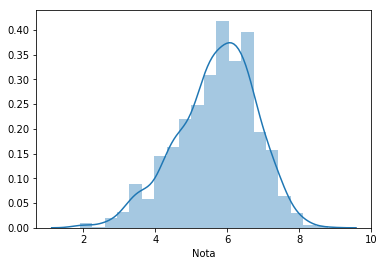

```python
# Conbertim un nombre amb format XX,XX i guardat com una string a un nombre en format decimal estàndar (XX.XX)
FA_clean['Nota'] = [float(nota.replace(',','.')) for nota in FA_clean['Nota']]

# Visualitzem la distribució de les puntuacions
sns.distplot(FA_clean['Nota'], bins = 20)
```

A partir de la gràfica de distribució anterior, veiem que segyurament no podrem suposar normalitat en la distribució de les notes i, a més, té cues pesades pel cantó esquerre (per tant, una skew negativa).

Anem a veure si es pot suposar normalitat i calculem quins són els seus estadístics:

```python
# Realitzem un test de normalitat
print('Valor promig de les votacions: ', np.mean(FA_clean['Nota']))
print('Mediana de les votacions: ', np.median(FA_clean['Nota']))
print(sp.stats.normaltest(FA_clean['Nota']))

# Per a més informació sobre el test utilitzat, consultar el seu manual:
# https://docs.scipy.org/doc/scipy/reference/generated/scipy.stats.normaltest.html
```

```
Valor promig de les votacions:  5.694870349492676
Mediana de les votacions:  5.8
NormaltestResult(statistic=55.77169754614241, pvalue=7.750500607935107e-13)
```

Com que el p-valor << 0.005, podem assegurar amb un 99% de confiaça, que la distribució no segueix una normal.

Per acabar aquesta segona secció d'anàlisi de variables quantitatives, anem a analitzar el nombre de votacions que hi ha i com es distribueix. Abans però, haurem de realitzar alguna conversió perquè s'ha realitzat una descàrrega errònia dels valors (format XXX.XXX,XXX i hauria de ser XXX,XXX.XXX):

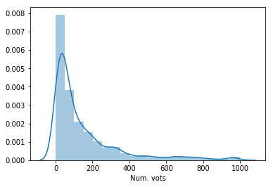

```python
FA_clean['Num. vots'] = FA_clean['Num. vots']*1000
sns.distplot(FA_clean['Num. vots'], bins = 20)
```

Veiem que hi ha un clar biaix cap a les películes amb poques votacions com es pot veure amb la dispersió entre els quartilsa de la distribució:

```python
print('Promig del nombre de vots: ',np.mean(FA_clean['Num. vots']))
print('Percentil 25% del nombre de vots: ',np.quantile(FA_clean['Num. vots'], .25))
print('Percentil 50% del nombre de vots: ',np.quantile(FA_clean['Num. vots'], .5))
print('Percentil 75% del nombre de vots: ',np.quantile(FA_clean['Num. vots'], .75))
print('Percentil 100% del nombre de vots: ',np.quantile(FA_clean['Num. vots'], 1))
```

```
Promig del nombre de vots:  148.34442784667414
Percentil 25% del nombre de vots:  30.0
Percentil 50% del nombre de vots:  71.0
Percentil 75% del nombre de vots:  186.0
Percentil 100% del nombre de vots:  998.0
```

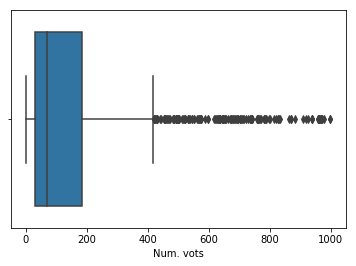

```python
# Dibuixem un diagrama de caixes on veiem que hi ha certs registres molt extrems
sns.boxplot(FA_clean['Num. vots'])
```

**PAS 3. VISUALITZACIÓ DE LES DADES CATEGÒRIQUES**

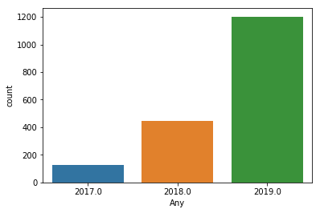

```python
# Any de la publicació
sns.countplot(FA_clean['Any'])
```

Com veiem, la gran majoria de películes són de l'any 2019 perquè suposo el motor de cerca primera mostrava les d'aquest any per a cada país seleccionat i llavors les dels anys següents si no hin havia més resultats.

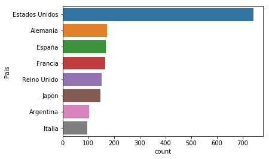

```python
# País del film
sns.countplot(y = 'Pais', data = FA_clean, order = FA_clean['Pais'].value_counts().index[0:8])
```

Mostrem els 8 primers elements, on veiem que EEUU té clarament una sobreponderació respecte la resta de països.

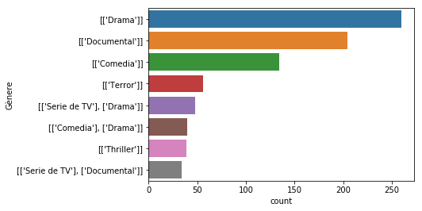

```python
# Gènere del film
sns.countplot(y = 'Gènere', data = FA_clean, order = FA_clean['Gènere'].value_counts().index[0:8])
```

Com veiem, les fiulmacions més emmagtemades són documentals i drames però ens trobem que potser no està ben parametritzat perquè la nostra base ha baixat una llista enlloc de classificar-ho individualment. Així, haurem de separar tots els gèneres i convertir aquesta columna en múltiples columnes bonàries, cada una representant un únic gènere:

```python
# Comencem saben quins elements hi ha
uni_gen = FA_clean['Gènere'].unique()

# Separem el llistat de caràcters utilitzant "'"
uni_gen = [gen.split("'") for gen in uni_gen]

# Aplenem la llista
uni_gen = [txt for sub in uni_gen for txt in sub]

# Eliminem les cadenes de text que no són paraules
uni_gen = [txt for txt in uni_gen if (txt !='[[')]
uni_gen = [txt for txt in uni_gen if (txt !='], [')]
uni_gen = [txt for txt in uni_gen if (txt !=']]')]

# Ens quedem amb les úniques aparicions
uni_gen = pd.Series(uni_gen).unique()
```

```python
# Creem un DF per fer les dummies dels gèneres
df_gen = pd.DataFrame(np.zeros((len(FA_clean['Gènere']),len(uni_gen))),columns=uni_gen)

# Per a cada película, repetim el mateix procediment
for i in range(len(FA_clean['Gènere'])):
    gen = FA_clean['Gènere'][i]
    gen = gen.split("'")
    gen = [txt for txt in gen if (txt !='[[')]
    gen = [txt for txt in gen if (txt !='], [')]
    gen = [txt for txt in gen if (txt !=']]')]
    for col in df_gen.columns:
        for g in gen:
            if g == col:
                df_gen[col][i] = 1

# Concatenem els dos dataframes
FA_clean = pd.concat([FA_clean, df_gen], axis = 1)

# Eliminem la columna antiga de gèneres
FA_clean = FA_clean.drop('Gènere', axis = 1)
```

Un cop tenim creada correctament el desglòs per cada gènere dioferent, anem a veure quins gèneres estan més representats en el nostre dataset:

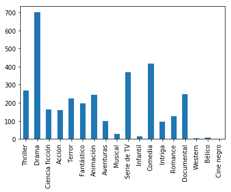

```python
# Creem un vector per emmagatzemar el nombre de películes en cada gènere
sum_gen = [FA_clean[gen].sum() for gen in uni_gen]
sum_gen = pd.Series(sum_gen, index=uni_gen)

# Dibuixem els resultats
sum_gen.plot.bar()
```

A la vista del gràfic, veiem que el gènere més representat és el de 'Drama' seguit de molt lluny per 'Comedia' i 'Sèrie de TV' (els 3 grans gèneres que hi ha a FA tot i que aquest últim no es podria considerar un gènere pròpiament dit).

**PAS 4. ANÀLISIS ESTADÍSTICS:**

4.1. Relació entre nombre de votacions i valoració de la película: Comencem analitzant si existeix una relació entre nombre de votacions i valoració del film segons els usuaris de FA. Per fer-ho, dibuixarem un gràfic creuat i calcularem el seu regressor lineal, tot calculant R^2:

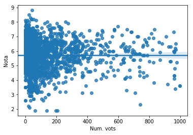

```python
# Dibuixem el regressor
sns.regplot(x='Num. vots', y='Nota', data=FA_clean)
```

Com ens podíem esperar, no existeix una relació que impliqui que a major votació millor nota. Tot i així, farem l'exercici de calcular la seva regressió lineal:

```python
# Impertem la llibreria per realitzar les regressions
import statsmodels.api as sm
# Per a més informació, consultar: https://www.statsmodels.org/stable/index.html

# Calculem la regressió
model = sm.OLS(FA_clean['Nota'], FA_clean['Num. vots']).fit()
model.summary()
```

OLS Regression Results

| Dep. Variable: | Nota | R-squared: | 0.364 |
| --- | --- | --- | --- |
| Model: | OLS | Adj. R-squared: | 0.363 |
| Method: | Least Squares | F-statistic: | 1013. |
| Date: | Tue, 07 Jan 2020 | Prob (F-statistic): | 3.51e-176 |
| Time: | 12:24:50 | Log-Likelihood: | -5234.6 |
| No. Observations: | 1774 | AIC: | 1.047e+04 |
| Df Residuals: | 1773 | BIC: | 1.048e+04 |
| Df Model: | 1 |  |  |
| Covariance Type: | nonrobust |  |  |

|  | coef | std err | t | P>\|t\| | [0.025 | 0.975] |
| --- | --- | --- | --- | --- | --- | --- |
| Num. vots | 0.0145 | 0.000 | 31.823 | 0.000 | 0.014 | 0.015 |

| Omnibus: | 642.412 | Durbin-Watson: | 0.385 |
| --- | --- | --- | --- |
| Prob(Omnibus): | 0.000 | Jarque-Bera (JB): | 2198.023 |
| Skew: | -1.807 | Prob(JB): | 0.00 |
| Kurtosis: | 7.084 | Cond. No. | 1.00 |

Warnings:  
[1] Standard Errors assume that the covariance matrix of the errors is correctly specified.

4.2. Hi ha un país amb millor valoració que la resta? Per començar, escriurem tots els promitgos de valoracions per a cada país per saber de quin país partir:

```python
[print('La nota promig del país ' + pais + ' és: ', np.mean(FA_clean[FA_clean['Pais'] == pais]['Nota']))
     for pais in FA_clean['Pais'].value_counts()[0:8].index]
```

```
La nota promig del país Estados Unidos és:  5.655870445344126
La nota promig del país Alemania és:  5.2238372093023235
La nota promig del país España és:  5.489880952380953
La nota promig del país Francia és:  5.814545454545456
La nota promig del país Reino Unido és:  5.882894736842103
La nota promig del país Japón és:  6.271232876712332
La nota promig del país Argentina és:  5.617475728155339
La nota promig del país Italia és:  5.824742268041236
```

```
[None, None, None, None, None, None, None, None]
```

Ens quedem només amb els 8 països amb més pel·lícules perquè la resta de països que apareixien en el llistat només disposaven de menys d'una desena de películes i els resultats estadístics obtinguts no haguessin estat vàlids.

A partir del llistat anterior, veiem que Japó disposa d'una valoració mitjana sensiblement superior a la resta i, per tant, és la nostra candidata a ser utilitzada pel test:

```python
# Creem dos vectors diferents que serviranmm per aplicar-los el test
jap = FA_clean[FA_clean['Pais'] == 'Japón']['Nota']
njap = FA_clean[FA_clean['Pais'] != 'Japón']['Nota']
```

Per aquest anàlisi, utilitzarem el test de Mann-Wjitney U (https://en.wikipedia.org/wiki/Mann%E2%80%93Whitney_U_test) ja que ambdós mostres pertanyen a la mateixa distribució original i, com hem vist amb anterioritat, no tenen una distribució normal:

```python
# Per a més informació de la funció utilitzada, consultar:
# https://docs.scipy.org/doc/scipy/reference/generated/scipy.stats.mannwhitneyu.html
print(sp.stats.mannwhitneyu(jap,njap,alternative='two-sided'))
print(sp.stats.mannwhitneyu(jap,njap,alternative='greater'))
```

```
MannwhitneyuResult(statistic=159288.0, pvalue=8.86367787152009e-12)
MannwhitneyuResult(statistic=159288.0, pvalue=4.431838935760045e-12)
```

4.3. Existeix algun gènere amb una puntuació superior a la resta? El procediment per respondre aquesta pregunta serà exacte al realitzat al sub-apartat anterior. Així, comencem mirant per a cada gènere quina és la seva nota promig:

```python
[print('La nota promig del gènere ' + gen + ' és: ', np.mean(FA_clean[FA_clean[gen] == 1]['Nota'])) for gen in uni_gen]
```

```
La nota promig del gènere Thriller és:  5.414981273408244
La nota promig del gènere Drama és:  5.838428571428571
La nota promig del gènere Ciencia ficción és:  5.56851851851852
La nota promig del gènere Acción és:  5.614374999999998
La nota promig del gènere Terror és:  5.028251121076233
La nota promig del gènere Fantástico és:  5.877157360406092
La nota promig del gènere Animación és:  6.176734693877549
La nota promig del gènere Aventuras és:  5.906122448979591
La nota promig del gènere Musical és:  5.996153846153846
La nota promig del gènere Serie de TV és:  6.173913043478261
La nota promig del gènere Infantil és:  5.45
La nota promig del gènere Comedia és:  5.416385542168674
La nota promig del gènere Intriga és:  5.6074468085106375
La nota promig del gènere Romance és:  5.312903225806452
La nota promig del gènere Documental és:  6.432113821138211
La nota promig del gènere Western és:  6.366666666666667
La nota promig del gènere Bélico és:  6.277777777777779
La nota promig del gènere Cine negro és:  6.1
```

```
[None,
 None,
 None,
 None,
 None,
 None,
 None,
 None,
 None,
 None,
 None,
 None,
 None,
 None,
 None,
 None,
 None,
 None]
```

Notem que el gènere amb més bona valoració és el Documental però com aquest no és un gènerie pñròpiament dit, escollirem el 2n en la classificació ('Western'). Llavors, aplicarem el mateix test estadístic anterior per comprovar si aquesta diferència resdpecte els altres gèneres és estadísticament significativa:

```python
# Creem dos vectors diferents que serviran per aplicar-los el test
west = FA_clean[FA_clean['Western'] == 1]['Nota']
nwest = FA_clean[FA_clean['Western'] != 1]['Nota']

# Apliquem el test
sp.stats.mannwhitneyu(west,nwest,alternative='two-sided')
```

```
MannwhitneyuResult(statistic=3714.0, pvalue=0.23292472077900994)
```

Com que el p-valor està per sobre del valor crític, no podem rebutjar la hipòtesis nul·la i, per tant, no podem realitzar cap conclusió estadística significativa.

Alternativament, podríem mirar si les películes de Terror són les pitjor valorades:

```python
# Creem dos vectors diferents que serviran per aplicar-los el test
ter = FA_clean[FA_clean['Terror'] == 1]['Nota']
nter = FA_clean[FA_clean['Terror'] != 1]['Nota']

# Apliquem el test
print(sp.stats.mannwhitneyu(ter,nter,alternative='two-sided'))
print(sp.stats.mannwhitneyu(ter,nter,alternative='less'))
```

```
MannwhitneyuResult(statistic=101082.0, pvalue=9.164169029659309e-24)
MannwhitneyuResult(statistic=101082.0, pvalue=4.5820845148296544e-24)
```

Com que els dos p-valors estan molt per sota de qualsevol valor crític, podem establir que les películes de terror són les pitjor valorades pels usuaris de FA de tots els gèneres disponibles.

4.4. Els documentals estan més ben valorats que les sèries de TV? El procediment per respondre aquesta última pregunta serà exacte al realitzat als dos sub-apartats anteriors:

```python
# Creem dos vectors diferents que serviran per aplicar-los el test
stv = FA_clean[FA_clean['Serie de TV'] == 1]['Nota']
doc = FA_clean[FA_clean['Documental'] == 1]['Nota']

# Apliquem el test
print(sp.stats.mannwhitneyu(stv,doc,alternative='two-sided'))
print(sp.stats.mannwhitneyu(stv,doc,alternative='less'))
```

```
MannwhitneyuResult(statistic=39201.5, pvalue=0.004852926669383144)
MannwhitneyuResult(statistic=39201.5, pvalue=0.002426463334691572)
```

Tot i que la prova de diferència de mitjanes no és tan significativa com les obtingudes amb els altres anàlisis, quan realitzem els dos tests obtenim que sí que hi ha una diferència significativa (perquè ambdos valors estan per sota de qualsevol valor crític) i, per tant, podem establir que, pels usuaris de FA, els documentals són millors que les sèries de TV.

4.5. Els curtmetratges estan més ben valorats que els llargmetratges? Per contestar a aquesta pregunta, binaritzarem l'atribut Duració i compararem les notes obtingudes per cada classe:

```python
# Definirem com a curtmetratge qualsevol film de menys de 30 min (https://es.wikipedia.org/wiki/Cortometraje)
curt = FA_clean[FA_clean['Duracio (min)'] <= 30]['Nota']
llarg = FA_clean[FA_clean['Duracio (min)'] > 30]['Nota']

#Escrivim les mitjanes
print('Vot promig dels curtmetratges: ', np.mean(curt))
print('Vot promig dels llargmetratges: ', np.mean(llarg))

# Apliquem el test
print(sp.stats.mannwhitneyu(curt,llarg,alternative='two-sided'))
print(sp.stats.mannwhitneyu(curt,llarg,alternative='greater'))
```

```
Vot promig dels curtmetratges:  5.881172839506171
Vot promig dels llargmetratges:  5.65324137931034
MannwhitneyuResult(statistic=260512.5, pvalue=0.002113746379591839)
MannwhitneyuResult(statistic=260512.5, pvalue=0.0010568731897959195)
```

**PAS 5. GENERACIÓ DEL CSV FINAL**

```python
#Generem el fitxer CSV amb el data clean
FA_clean.to_csv('FA_clean.csv')
```